# ASA_Script_missMDA

CLEMOT Bastien

2023-10-14

# Packages

```r
library(corrplot)
library(ade4)
library(lubridate)  # Convertir donnÃ©es temporelles en secondes
library(car)  # Fonction vif() et anova()
library(lme4)  # ModÃ¨le gaussien mixte
library(missMDA)
library(plyr)
```

# Importer les data

Le fichier de données possède 32 variables métaboliques, génotypiques et environementales.

```r
data <- read.table(
  file = "ASA_data_projet.txt",
  stringsAsFactors = T,
  header = T,
  na.strings = "NA",
  dec = ",",
  sep = ""
)
```

# Data cleaning

### — Renomme les variables

On renomme les variables avec des noms plus simples.

```r
colnames(data)[1:22] <- c(
  "ID",
  "eclosion_day",
  "sex",
  "FMR_day",
  "age_FMR",
  "mass",
  "FMR",
  "flight_day",
  "age_flight",
  "sun_flight",
  "wind_flight",
  "air_T",
  "dew_flight",
  "humidity_flight",
  "solar_radiation_flight",
  "flight_duration",
  "disturbed_flight",
  "stop_flight",
  "takeoff_time",
  "takeoff_T_thorax",
  "end_flight_time",
  "mean_T_flight"
)
```

### — Supprime la colonne “ID”

```r
data <- data[, !colnames(data) %in% "ID"]
```

### — Conversion des variables “heures” en seconde

```r
data$takeoff_time <-  format(as.POSIXct(data$takeoff_time, format = "%H:%M:%S"), format = "%H:%M:%S")
data$end_flight_time <-  format(as.POSIXct(data$end_flight_time, format = "%H:%M:%S"), format = "%H:%M:%S")
```

### — Extraire les heures, les minutes et les secondes

```r
for (variable_name in c("takeoff_time", "end_flight_time")){

  data[, variable_name] <- hms(data[, variable_name])
  heures <- hour(data[, variable_name])
  minutes <- minute(data[, variable_name])
  secondes <- second(data[, variable_name])

  # Convertir les heures, les minutes et les secondes en secondes
  data[, variable_name] <- heures * 3600 + minutes * 60 + secondes
}
```

### — Conversion des variables “facteurs”

```r
data$wind_flight <- as.factor(data$wind_flight)
data$sun_flight <- as.factor(data$sun_flight)
data$age_FMR <- as.factor(data$age_FMR)
```

### — Identification et visualisation des donnÃ©es manquantes

```r
# Identification des NAs par variables (en %)
data_na <-
  apply(
    X = data,
    MARGIN = 2,
    FUN = function(x) round(sum(is.na(x)) / nrow(data) * 100, 2)
  )
```

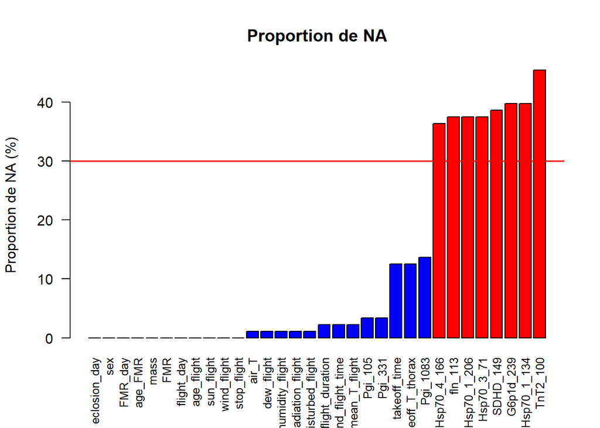

```
## démarrage du serveur d'aide httpd ... fini
```

# Imputation des NAs

[output not shown]

On a donc bien plus aucun NAs.

**Renommage des levels**

La fonction change le nom des levels, on va donc les réatribuer comme précédemment par soucis de clareté.

```r
noNA_data$age_FMR <- mapvalues(noNA_data$age_FMR, from = levels(noNA_data$age_FMR), to = levels(data$age_FMR))
noNA_data$sun_flight <- mapvalues(noNA_data$sun_flight, from = levels(noNA_data$sun_flight), to = levels(data$sun_flight))
noNA_data$wind_flight <- mapvalues(noNA_data$wind_flight, from = levels(noNA_data$wind_flight), to = levels(data$wind_flight))
noNA_data$disturbed_flight <- mapvalues(noNA_data$disturbed_flight, from = levels(noNA_data$disturbed_flight), to = levels(data$disturbed_flight))
noNA_data$stop_flight <- mapvalues(noNA_data$stop_flight, from = levels(noNA_data$stop_flight), to = levels(data$stop_flight))
noNA_data$fln_113 <- mapvalues(noNA_data$fln_113, from = levels(noNA_data$fln_113), to = levels(data$fln_113))
noNA_data$G6p1d_239 <- mapvalues(noNA_data$G6p1d_239, from = levels(noNA_data$G6p1d_239), to = levels(data$G6p1d_239))
noNA_data$Hsp70_1_206 <- mapvalues(noNA_data$Hsp70_1_206, from = levels(noNA_data$Hsp70_1_206), to = levels(data$Hsp70_1_206))
noNA_data$Hsp70_1_134 <- mapvalues(noNA_data$Hsp70_1_134, from = levels(noNA_data$Hsp70_1_134), to = levels(data$Hsp70_1_134))
noNA_data$Hsp70_3_71 <- mapvalues(noNA_data$Hsp70_3_71, from = levels(noNA_data$Hsp70_3_71), to = levels(data$Hsp70_3_71))
noNA_data$Hsp70_4_166 <- mapvalues(noNA_data$Hsp70_4_166, from = levels(noNA_data$Hsp70_4_166), to = levels(data$Hsp70_4_166))
noNA_data$Pgi_105 <- mapvalues(noNA_data$Pgi_105, from = levels(noNA_data$Pgi_105), to = levels(data$Pgi_105))
noNA_data$Pgi_1083 <- mapvalues(noNA_data$Pgi_1083, from = levels(noNA_data$Pgi_1083), to = levels(data$Pgi_1083))
noNA_data$Pgi_331 <- mapvalues(noNA_data$Pgi_331, from = levels(noNA_data$Pgi_331), to = levels(data$Pgi_331))
noNA_data$SDHD_149 <- mapvalues(noNA_data$SDHD_149, from = levels(noNA_data$SDHD_149), to = levels(data$SDHD_149))
noNA_data$TnT2_100 <- mapvalues(noNA_data$TnT2_100, from = levels(noNA_data$TnT2_100), to = levels(data$TnT2_100))
data <- noNA_data
```

#### — Visualisation des distribution des X

**Facteurs**

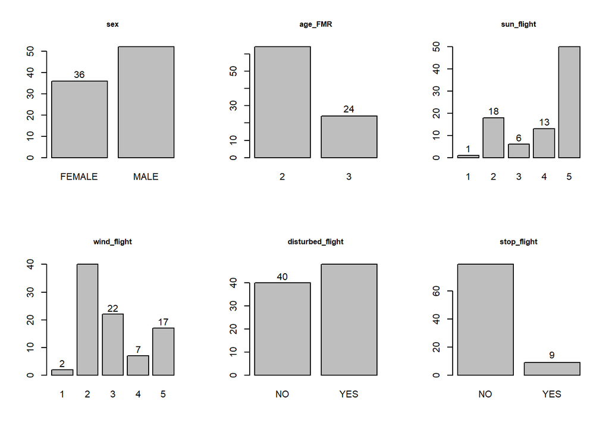

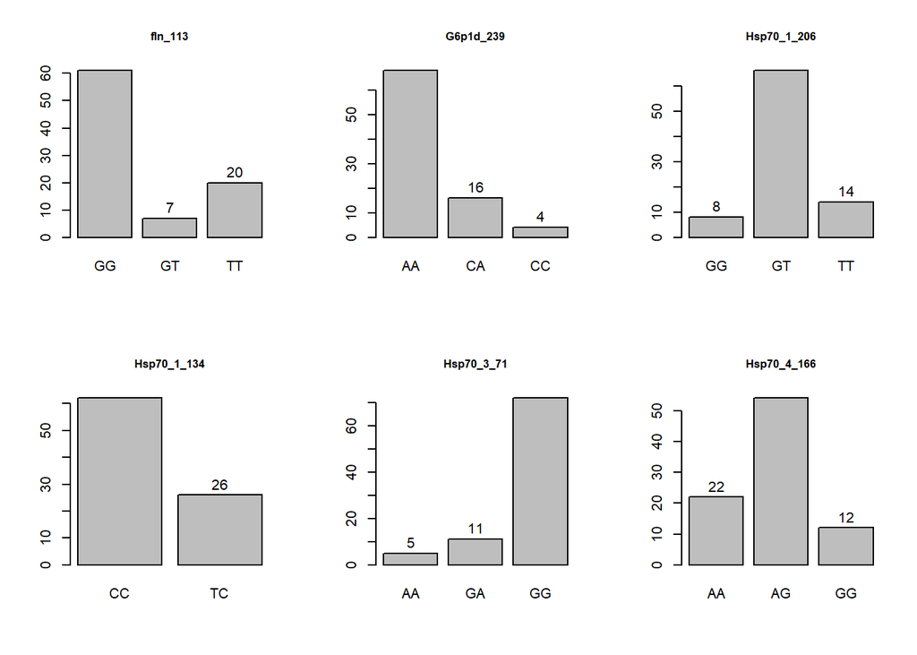

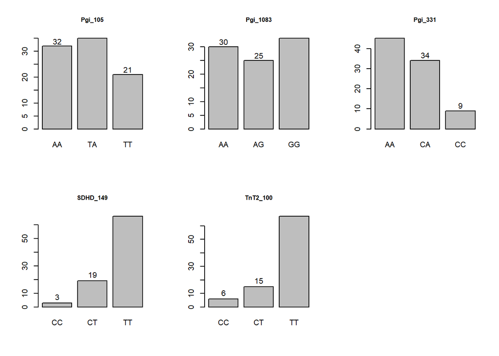

```r
data_factor <- data[,sapply(data, is.factor)]  # factor columns identification

par(mfrow = c(2, 3))
i <- 1
visu <- apply(X = data_factor, MARGIN = 2,
      function(x) {
        bar <- barplot(table(x),main = colnames(data_factor)[i], cex.main = .8)
        text(
          x = bar,
          y = table(x) - 1,
          label = table(x),
          pos = 3
        )

        i <<- i + 1
      }
)
```

Les variables sun_flight et wind_flight ont une modalité (“1”) avec respectivement, 1 et 2 réplicats. Ces modalités sont alors inutilisables. On créé donc une autre modalité : “<2”.

```r
# Reformatage
data$sun_flight <- ifelse(
    test = data$sun_flight == 1 | data$sun_flight == 2,
    yes = "<2",
    no = data$sun_flight
  )

data$wind_flight <- ifelse(
    test = data$wind_flight == 1 | data$wind_flight == 2,
    yes = "<2",
    no = data$wind_flight
  )

# Conversion en facteur
data$sun_flight  <- as.factor(data$sun_flight)
data$wind_flight <- as.factor(data$wind_flight)
```

Revisualisation :

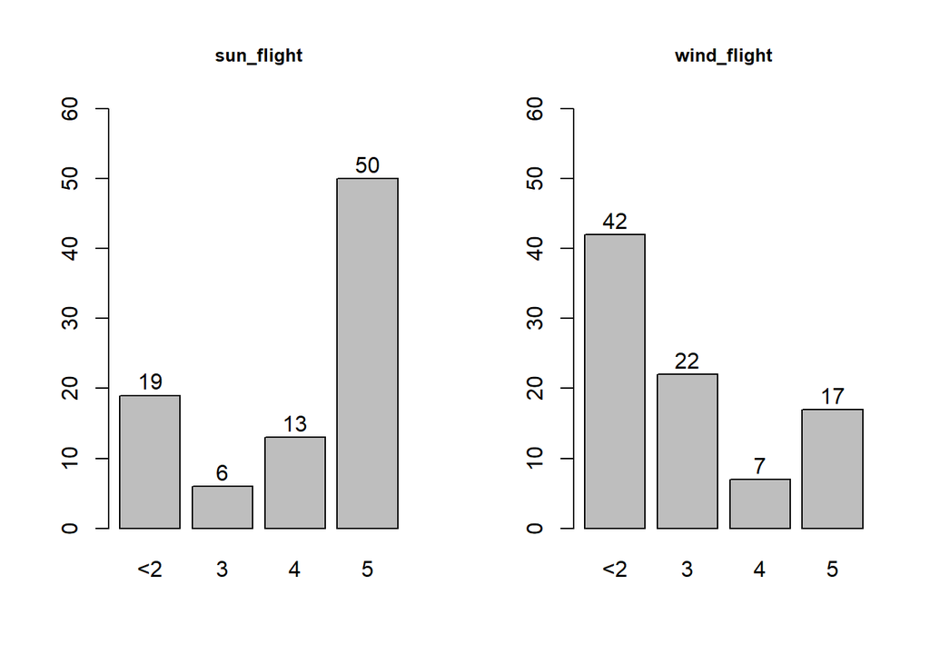

**Covariables**

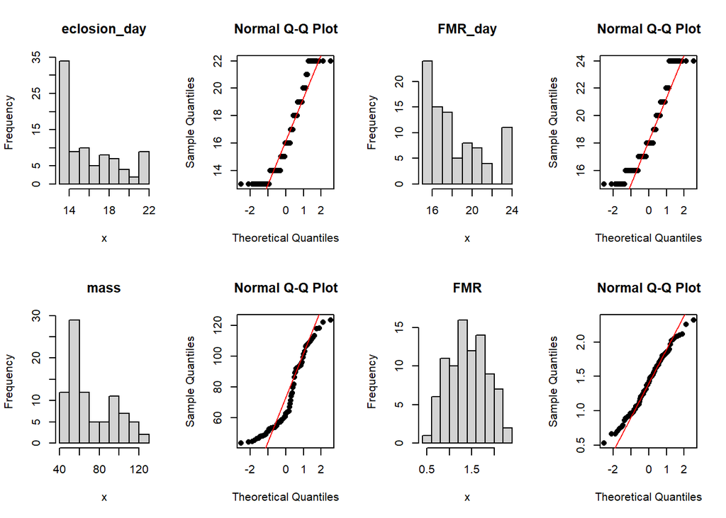

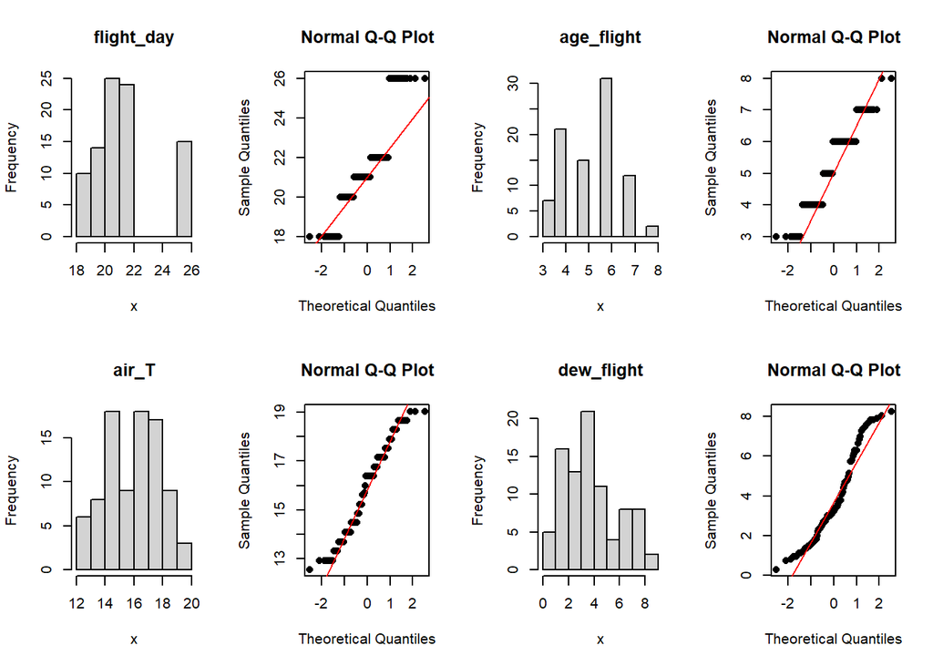

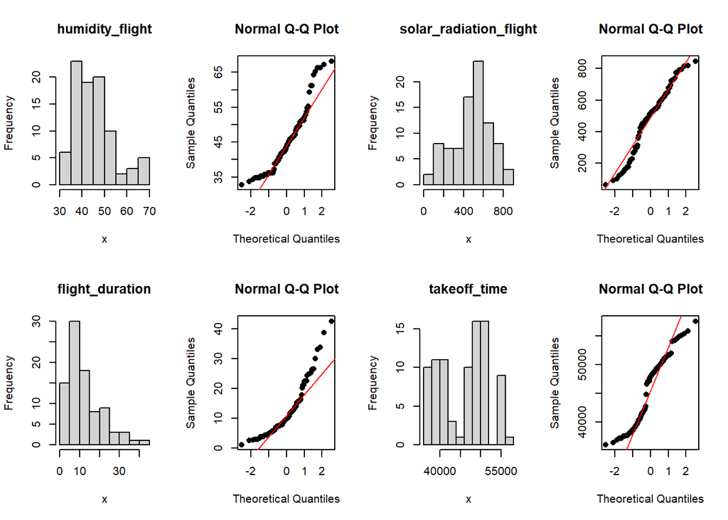

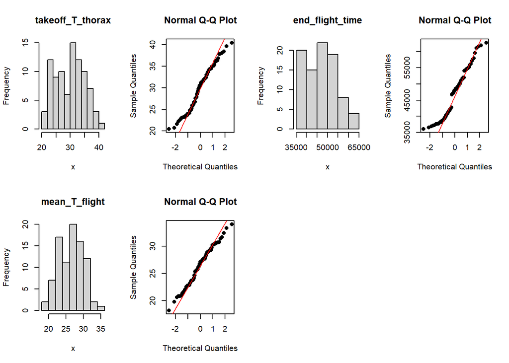

On transorme les variables suivantes avec le logaritme pour ‘normaliser’ la distribution :

- Eclosion day
- FMR_day
- mass
- flight_day
- humidity
- flight_duration
- takeoff_time

```r
data$eclosion_day <- log(data$eclosion_day)
data$mass <- log(data$mass)
data$FMR_day <- log(data$FMR_day)
data$flight_day <- log(data$flight_day)
data$humidity_flight <- log(data$humidity_flight)
data$flight_duration <- log(data$flight_duration)
data$takeoff_time <- log(data$takeoff_time)
```

### — Visualisation des distribution mean_T_flight ~ X

**Facteurs**

[figure not shown]

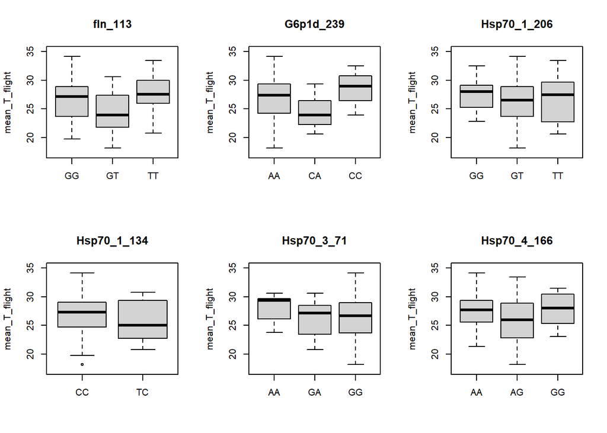

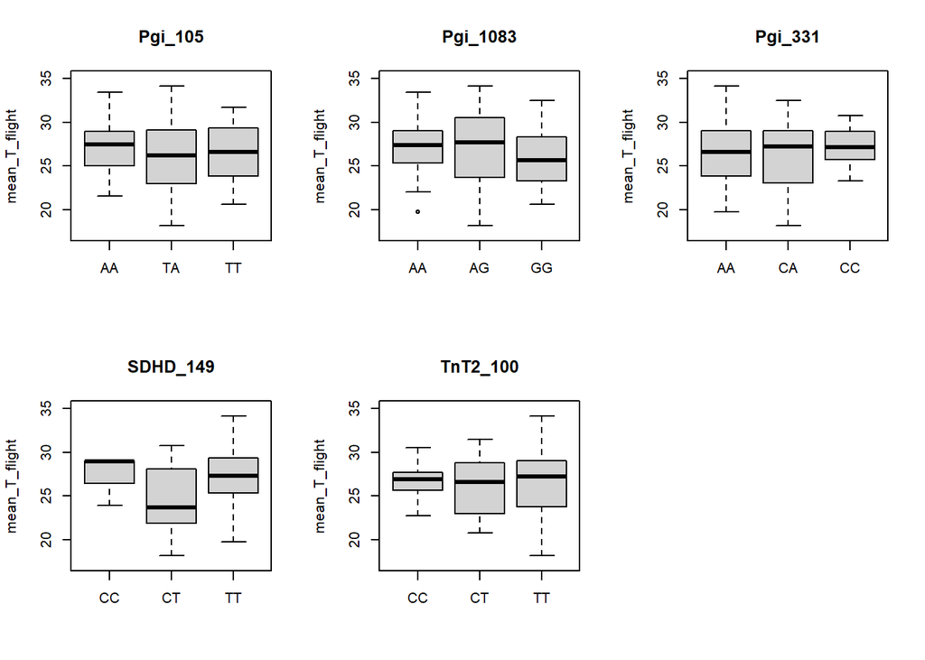

**Covariables**

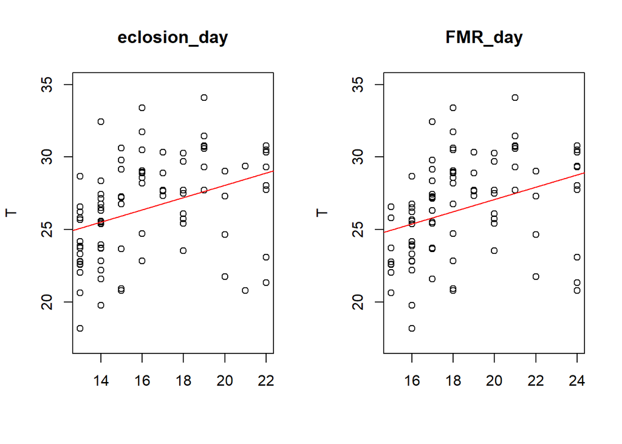

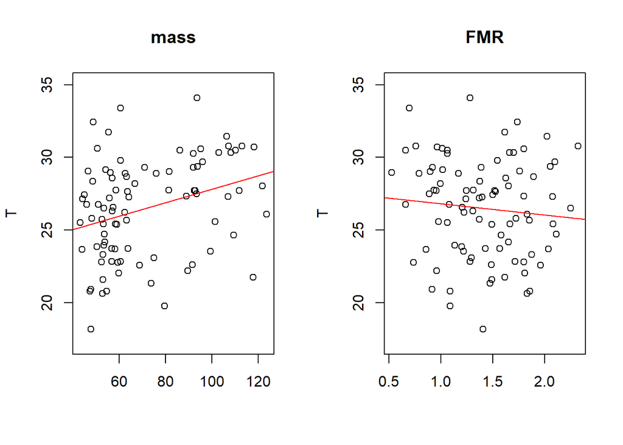

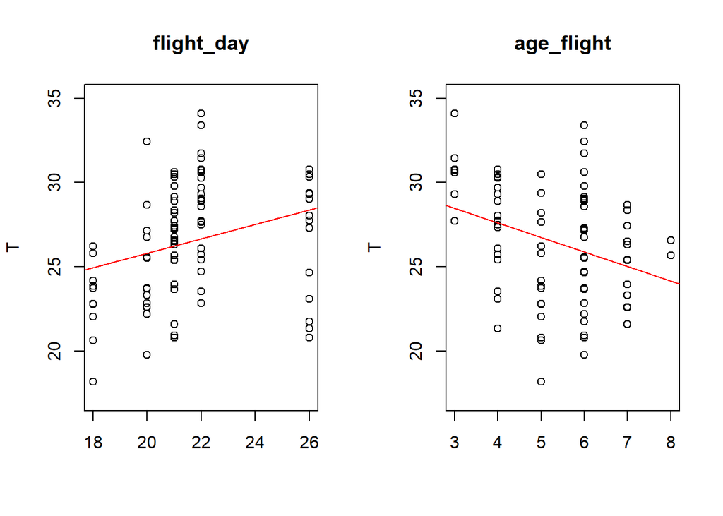

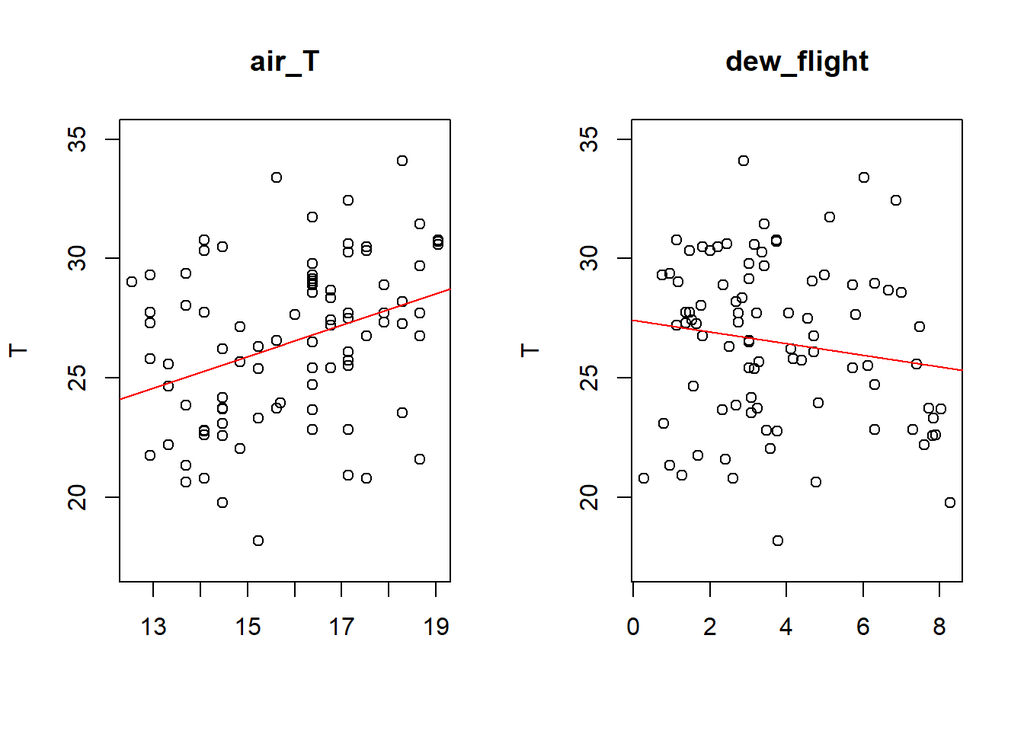

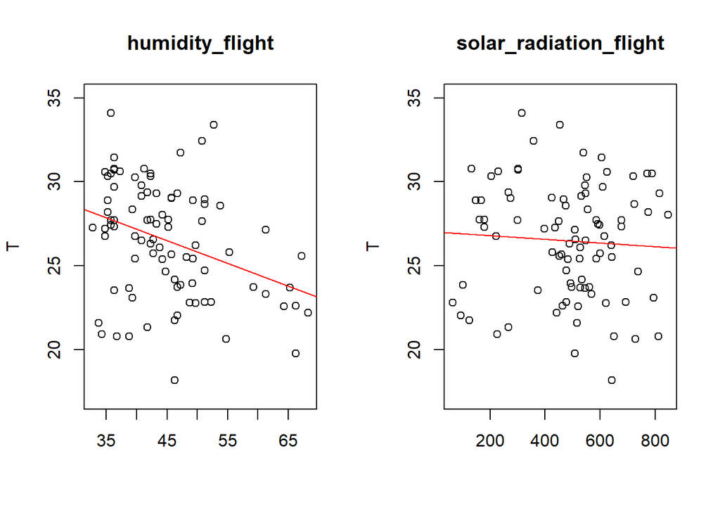

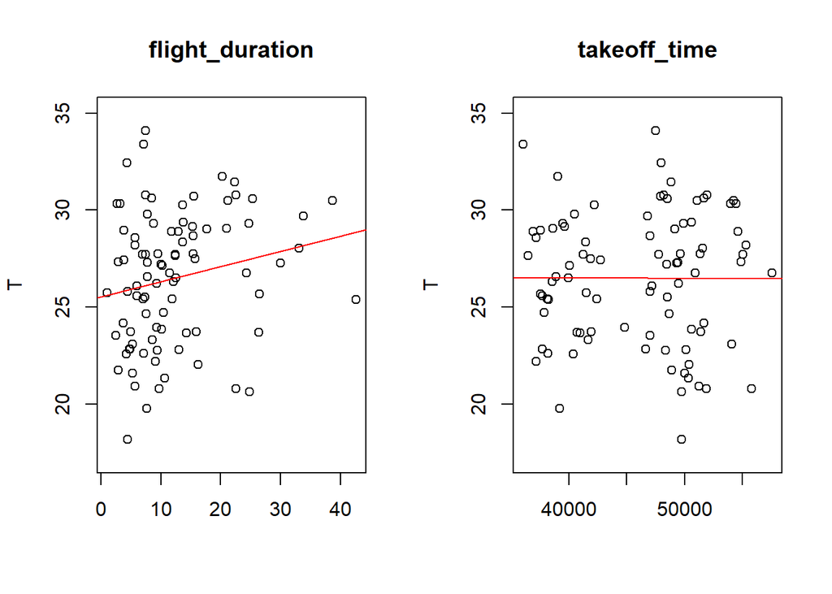

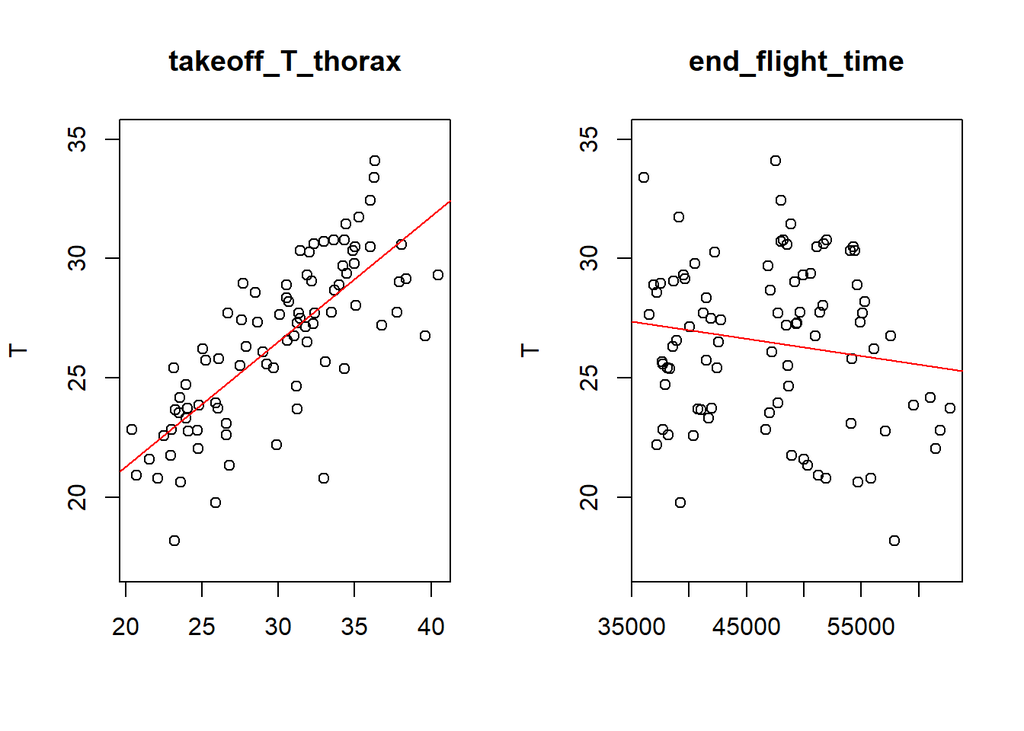

# IntÃ©ractions entre y ~ facteurs / co-variables

## A) GÃ¨ne * environnement

### — TempÃ©rature de l’air et SNP331 (ref : bibliographie)

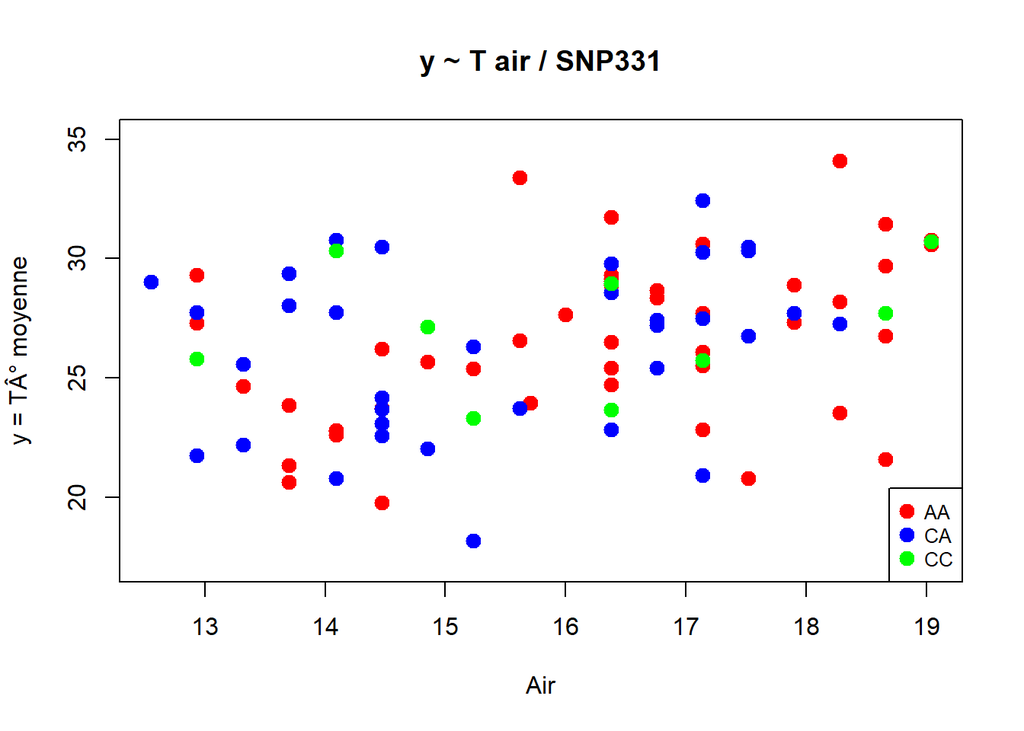

On observe pas de pattern clair d’interaction entre la température de l’air et le SNP331 (tous les groupes [couleurs] de points se chevauchent) sur la température du vol.

## B) Sexe * variables physiologiques et comportementales

### — y ~ Masse*sexe

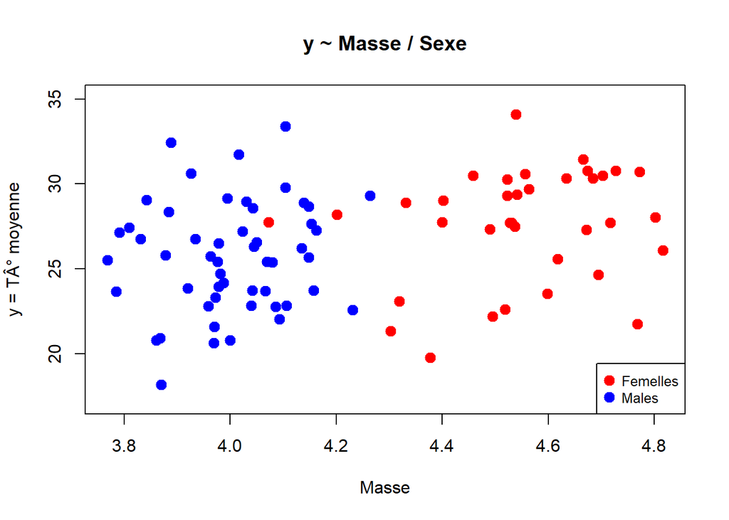

### — y ~ sexe*FMR

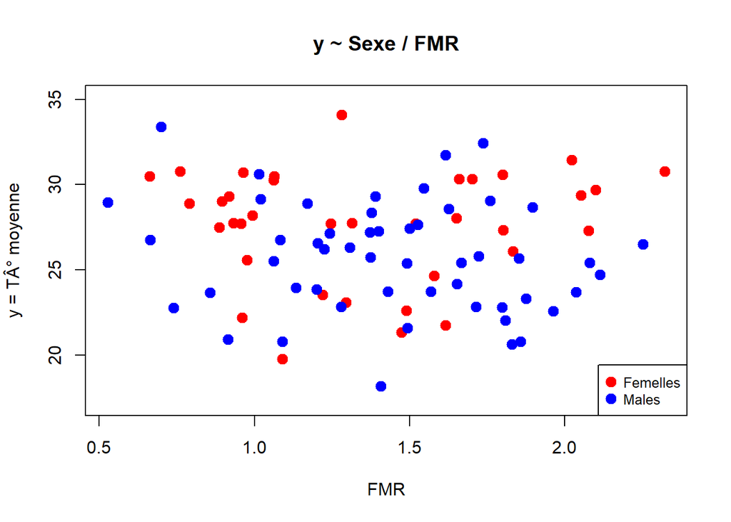

### — y ~ sexe*flight_duration

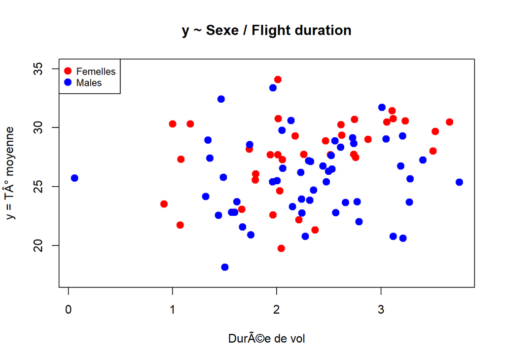

### — y ~ sexe*température au décollage

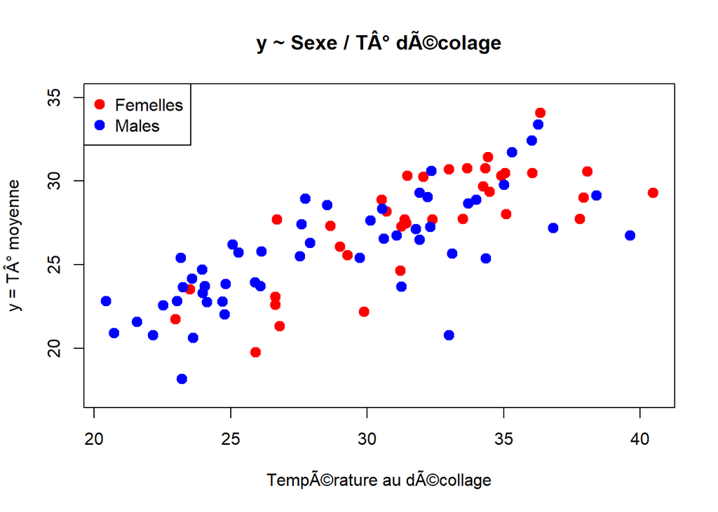

Pas d’interaction visible entre la température au décollage et le sexe.

### — y ~ sexe*SNP331

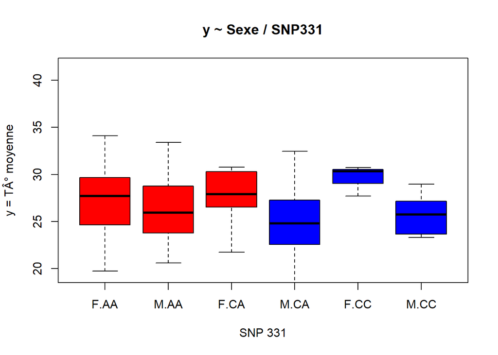

### — y ~ sexe*SNP105

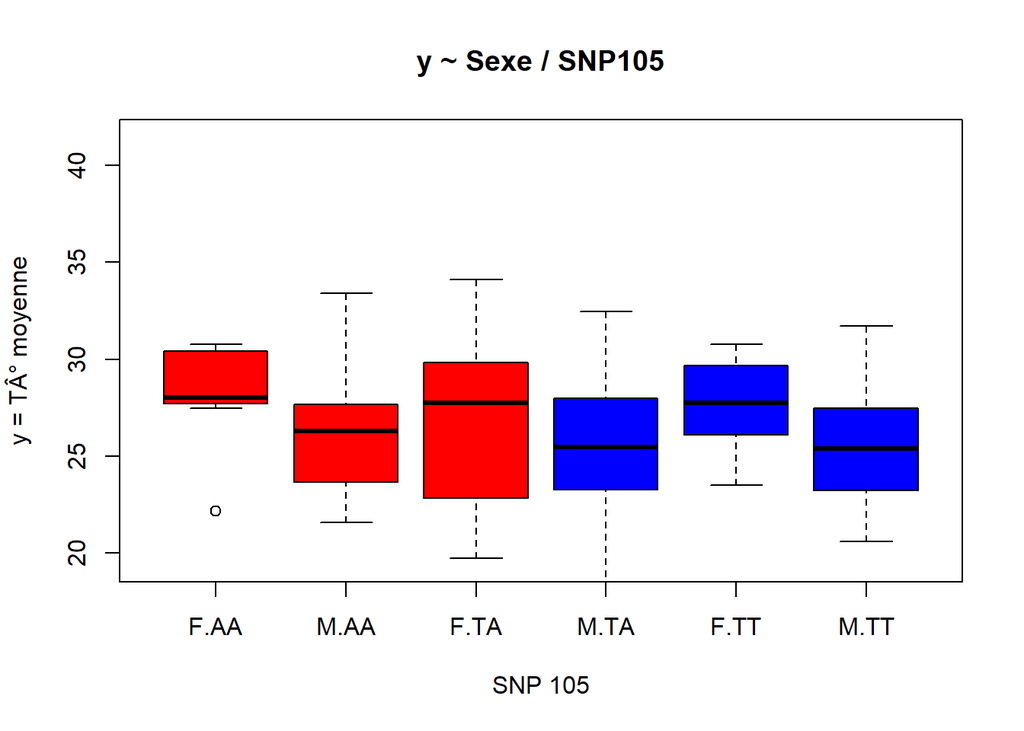

### — y ~ sexe*SNP1083

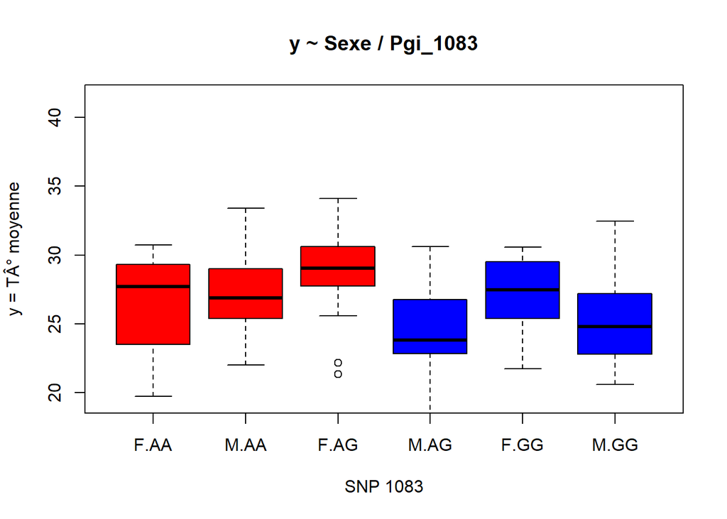

On observe de claires interactions entre les variables génétiques et le sexe du papillon sur la température du corps.

**Au vu des nombreuses interactions entre variables prédictives et sexes, nous avons décidé de mener les analyses en séparant les mâles et les femelles**.